# WUM - Projekt 2 - EDA

Konrad Komisarczyk, Mikołaj Malec, Patryk Wrona

5 maja 2020

# 1 Analiza wstępna zbioru danych i opis

W niniejszym projekcie będziemy dokonywać klasteryzacji zbioru reigijnych ksiąg azjatyckich oraz biblijnych. Zagadnienie to wymaga więcej kreatywności niż zagadnienia regresji i klasyfikacji.

W tej cześci projektu, czyli Exploratory Data Analysis, postaramy się jak najbliżej przyjrzeć się zbiorowi danych i możliwości jakie ze sobą niesie.

Najpierw załadujmy zbiór danych:

```r
books <- readRDS("./books.RDS")
```

Spójrzmy na parę pierwszych obserwacji:

```r
head(books)
```

|  | X | foolishness | hath | wholesome | takest | feelings | anger | vaivaswata | matrix | kindled | convict | diadem | rushed | saliva | revelation | indirectly | open | distortions | expecteth | perishing | rage | unbridled | looketh | washed | nursingmother | caper | prosperous | lightmindedness | imprisonment | … |
| --- | --- | --- | --- | --- | --- | --- | --- | --- | --- | --- | --- | --- | --- | --- | --- | --- | --- | --- | --- | --- | --- | --- | --- | --- | --- | --- | --- | --- | --- | --- |
| 1 | Buddhism | 0 | 0 | 0 | 0 | 0 | 0 | 0 | 0 | 0 | 0 | 0 | 0 | 0 | 0 | 0 | 1 | 0 | 0 | 0 | 0 | 0 | 0 | 0 | 0 | 0 | 0 | 0 | 0 | … |
| 2 | Buddhism | 0 | 0 | 0 | 0 | 0 | 0 | 0 | 0 | 0 | 0 | 0 | 0 | 0 | 0 | 0 | 0 | 0 | 0 | 0 | 0 | 0 | 0 | 0 | 0 | 0 | 0 | 0 | 0 | … |
| 3 | Buddhism | 0 | 0 | 0 | 0 | 0 | 0 | 0 | 0 | 0 | 0 | 0 | 0 | 0 | 0 | 0 | 0 | 0 | 0 | 0 | 0 | 0 | 0 | 0 | 0 | 0 | 0 | 0 | 0 | … |
| 4 | Buddhism | 0 | 0 | 0 | 0 | 0 | 0 | 0 | 0 | 0 | 0 | 0 | 0 | 0 | 0 | 0 | 0 | 0 | 0 | 0 | 0 | 0 | 0 | 0 | 0 | 0 | 0 | 0 | 0 | … |
| 5 | Buddhism | 0 | 0 | 0 | 0 | 0 | 0 | 0 | 0 | 0 | 0 | 0 | 0 | 0 | 0 | 0 | 0 | 0 | 0 | 0 | 0 | 0 | 0 | 0 | 0 | 0 | 0 | 0 | 0 | … |
| 6 | Buddhism | 0 | 0 | 0 | 0 | 0 | 0 | 0 | 0 | 0 | 0 | 0 | 0 | 0 | 0 | 0 | 0 | 0 | 0 | 0 | 0 | 0 | 0 | 0 | 0 | 0 | 0 | 0 | 0 | … |

W pierwszej kolumnie znajdują się odpowiednie rozdziały z danej księgi - w tym przypadku z księgi Buddyzmu. W kolejnych kolumnach jest liczba wystąpień danego słowa w obserwacji będącej chapterem(rozdziałem) rozważanej księgi.

Sprawdzimy czy w zbiorze danych są jakieś braki (chociaż wątpię):

```r
sum(is.na(books))
```

```
## [1] 0
```

Zatem w danych nie ma braków ni stąd ni zowąd - zbiory danych są dobrze zdefiniowane.

Sprawdźmy ile mamy ksiąg, a w nich rozdziałów:

```r
table(books$X)
```

```
##
## BookOfEccleasiasticus    BookOfEcclesiastes         BookOfProverb
##                    50                    12                    31
##          BookOfWisdom              Buddhism            TaoTeChing
##                    19                    46                    81
##             Upanishad             YogaSutra
##                   162                   189
```

```r
dim(books) #
```

```
## [1]  590 8267
```

Mamy 8 ksiąg, 590 rozdziałów, a liczba unikalnych słówek(kolumn) to 8266, ponieważ nie liczymy pierwszej kolumny.

Poniżej przedstawiamy liczbę rozdziałów (obserwacji) dla każdej księgi tak jak występują one z wbiorze danych:

- Buddhism 46
- TaoTeChing 81
- Upanishad 162
- YogaSutra 189
- BookOfProverb 31
- BookOfEcclesiastes 12
- BookOfEccleasiasticus 50
- BookOfWisdom 19

Sprawdzimy czy księgi różnią się objętościowo:

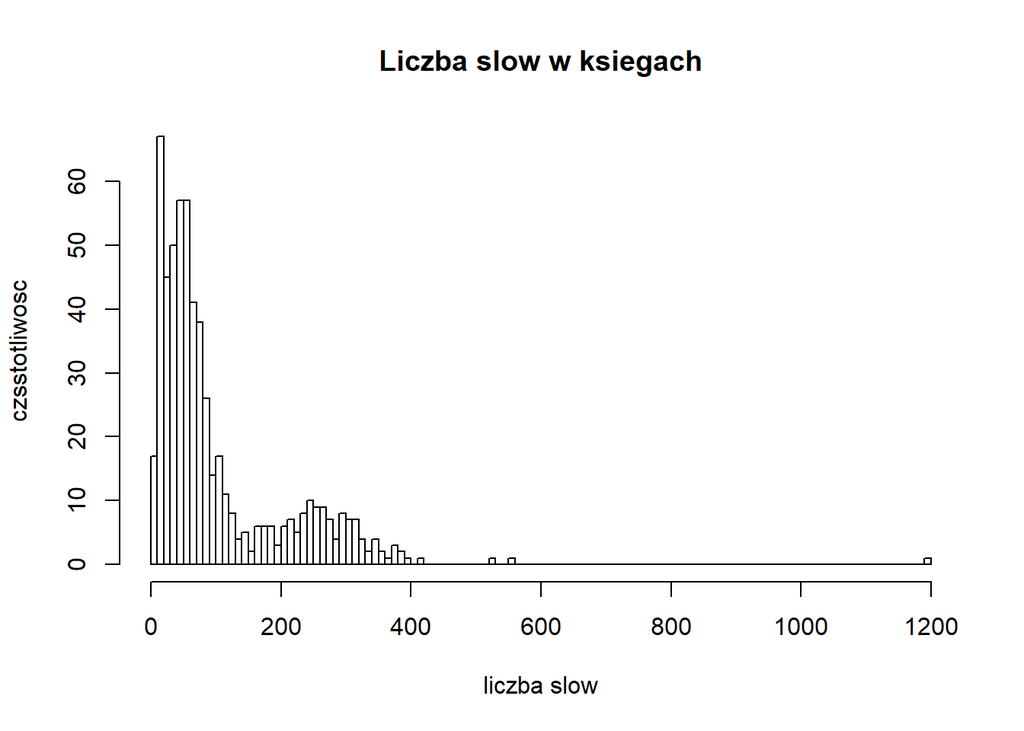

```r
aux <- as.matrix(books[,2:ncol(books)])
# sumuje słowa w każdym rozdziale:
liczba_slow <- apply(aux, 1, sum)
hist(liczba_slow, breaks = 100, main = "Liczba slow w ksiegach",
     xlab = "liczba slow",
     ylab = "czsstotliwosc")
```

Widać, że przeważają księgi, których rozdziały mają do 100 słów. Uwidacznia się również inna grupa - tych rozdziałów, które 200-400 słów. Być może będzie to cenna wskazówka w przyszłości.

# 2 Problemy na drodze do klasteryzacji

Niestety **klasteryzacja na tak wysoce wymiarowym zbiorze danych nie jest dobrym pomysłem** - musimy w pewien sposób zagregować nasze dane i **zmniejszyć ich wymiar**, aby móc w 2. kamieniu milowym rozpocząć wstępne modelowanie.

Oczywiście istnieją banalne sposoby agregacji typu *zliczanie ilości słów* w rozdziałach ksiąg, albo obliczanie *średniej długości słowa*. Jednakże, chcielibyśmy poszukać tych mniej oczywistych przekształceń. Rozważymy:

- zliczanie liczby rzeczowników, czasowników, przymiotników i przysłówków
- zliczanie liczby słówek o zadanej emocji spośród 7 wybranych typów emocji

Tutaj tylko ładujemy przekształcone zbiory danych. Kod pomocny w celu wygenerowania ich jest w pliku *eda2.R*.

# 3 Części mowy w poszczególnych księgach

W internecie łatwo znaleźć odpowiednie zbiory danych dotyczących słówek i odpowiadających im części mowy w języku angielskim. Odpowiednio zagregowaliśmy dane i otrzymaliśmy następujący rezultat:

```r
books2 <- readRDS("./speech_parts_aggregated.RDS")
head(books2, 10)
```

|  | X | noun | verb | adjective | adverb |
| --- | --- | --- | --- | --- | --- |
| 1 | Buddhism | 190 | 26 | 72 | 10 |
| 2 | Buddhism | 80 | 17 | 7 | 3 |
| 3 | Buddhism | 158 | 9 | 16 | 5 |
| 4 | Buddhism | 94 | 11 | 15 | 9 |
| 5 | Buddhism | 15 | 0 | 0 | 0 |
| 6 | Buddhism | 186 | 12 | 46 | 0 |
| 7 | Buddhism | 163 | 8 | 54 | 1 |
| 8 | Buddhism | 80 | 3 | 4 | 2 |
| 9 | Buddhism | 64 | 23 | 18 | 5 |
| 10 | Buddhism | 19 | 5 | 6 | 0 |

```r
tail(books2, 10)
```

|  | X | noun | verb | adjective | adverb |
| --- | --- | --- | --- | --- | --- |
| 581 | BookOfWisdom | 160 | 55 | 39 | 12 |
| 582 | BookOfWisdom | 196 | 60 | 48 | 21 |
| 583 | BookOfWisdom | 225 | 77 | 46 | 25 |
| 584 | BookOfWisdom | 147 | 34 | 19 | 17 |
| 585 | BookOfWisdom | 227 | 57 | 34 | 29 |
| 586 | BookOfWisdom | 166 | 36 | 23 | 12 |
| 587 | BookOfWisdom | 232 | 62 | 65 | 19 |
| 588 | BookOfWisdom | 157 | 41 | 28 | 20 |
| 589 | BookOfWisdom | 225 | 53 | 44 | 22 |
| 590 | BookOfWisdom | 178 | 46 | 37 | 23 |

Na pierwszy rzut oka, w Buddhism nie ma za wiele przysłówków (adverb), a w BookOfWisdom jest ich procentowo więcej.

Można również dostrzec, że w BookOfWisdom jest więcej słówek jako takich - te rozdziały są ‘większe objętościowo’. Postaramy się wziąć to pod uwagę *w następnym kamieniu milowym*, a samo zliczanie słówek jest łatwe w porównaniu do zastosowanych w tym projekcie przekształceń danych.

# 4 Emocje w poszczególnych księgach

W internecie znaleźliśmy zbiór słówek wraz z przyporządkowanym im emocjom. Niestety, zaledwie 10% słówek w naszych księgach miało zdefiniowane emocje - trudno się dziwić, w tych księgach są archaiczne słowa zazwyczaj nie analizowane w dzisiejszych czasach. Miejsmy nadzieję, że te 10% będzie reprezentatywne.

Odpowiednio zagregowaliśmy dane i otrzymaliśmy następujący rezultat:

```r
emotions <- readRDS("./emotions.RDS")
head(emotions, 20)
```

|  | X | surprise | sad | neutral | happy | anger | fear | disgust |
| --- | --- | --- | --- | --- | --- | --- | --- | --- |
| 1 | Buddhism | 4 | 15 | 3 | 9 | 2 | 0 | 0 |
| 2 | Buddhism | 2 | 1 | 0 | 5 | 8 | 0 | 0 |
| 3 | Buddhism | 2 | 2 | 5 | 6 | 31 | 4 | 0 |
| 4 | Buddhism | 1 | 0 | 1 | 14 | 15 | 2 | 0 |
| 5 | Buddhism | 0 | 0 | 0 | 1 | 0 | 0 | 0 |
| 6 | Buddhism | 8 | 3 | 0 | 19 | 10 | 9 | 0 |
| 7 | Buddhism | 20 | 7 | 26 | 10 | 1 | 1 | 0 |
| 8 | Buddhism | 1 | 0 | 0 | 1 | 2 | 1 | 0 |
| 9 | Buddhism | 0 | 1 | 0 | 2 | 2 | 0 | 0 |
| 10 | Buddhism | 0 | 0 | 0 | 0 | 0 | 0 | 0 |

[output cut: 10 more lines]

```r
tail(emotions, 20)
```

|  | X | surprise | sad | neutral | happy | anger | fear | disgust |
| --- | --- | --- | --- | --- | --- | --- | --- | --- |
| 571 | BookOfEccleasiasticus | 2 | 5 | 3 | 16 | 2 | 6 | 3 |
| 572 | BookOfWisdom | 0 | 1 | 2 | 13 | 2 | 4 | 1 |
| 573 | BookOfWisdom | 1 | 3 | 15 | 16 | 5 | 4 | 0 |
| 574 | BookOfWisdom | 2 | 3 | 4 | 16 | 2 | 11 | 0 |
| 575 | BookOfWisdom | 0 | 2 | 2 | 16 | 1 | 9 | 1 |
| 576 | BookOfWisdom | 10 | 0 | 3 | 9 | 1 | 8 | 0 |
| 577 | BookOfWisdom | 2 | 5 | 1 | 24 | 5 | 6 | 0 |
| 578 | BookOfWisdom | 4 | 9 | 6 | 18 | 6 | 5 | 0 |
| 579 | BookOfWisdom | 1 | 3 | 3 | 17 | 3 | 2 | 0 |
| 580 | BookOfWisdom | 1 | 1 | 0 | 7 | 1 | 5 | 1 |

[output cut: 10 more lines]

Możemy zauważyć, że Księdze Buddyzmu emocje są wymieszane, natomiast w Księdze Mądrości dominuje emocja “happy”, ale również “fear”. W Księdze Mądrości pojawia się również ‘disgust’, której to emocji brakuje w Księdze Buddyzmu.

# 5 Wnioski

W agregacji wzlędem emocji mamy 7 kolumn - na pierwszy rzut można było dostrzec różnice między Księgą Buddyzmu a Księgą Mądrości - być może dzieki takiemu przekształceniu danych będziemy mogli dokonać klasteryzacji.

W agregacji dotyczącej cześci mowy zamiast 8266 kolumn zostały nam tylko 4 - idealnie! :)

Po sprawdzeniu że w zbiorze jest różnorodność jeśli chodzi o liczbę słów w danym rozdziale księgi, nie wykonywaliśmy wykresów np. 3D, na które przyjdzie czas w następnym kamieniu milowym. **Jeden krok do klasteryzacji może polegać na podziale ksiąg na małe i duże objętościowo** jednakże ważne jest aby nie korzystać z tego faktu przy używaniu przekształconego zbioru danych dla emocji i części mowy - oczywistym jest fakt, że przedstawiając typowy wykres 3D, księgi większe zazwyczaj będą miały więcej słów o danych emocjach, zatem będa bardziej oddalone od początku układu współrzędnych. Taki wykres dawałby złudną nadzieję, że te większe księgi są bardziej nacechowane emocjonalnie.

W następnym kamieniu milowym dotyczącym **inżynierii cech i wstępnego modelowania** postaramy się odpowiednio przeskalować księgi, aby emocje i cześci mowy były zdefiniowane np. na 50 albo 100 słów.

Oczywiście nic nie stoi na przeszkodzie, aby połączyć nasze 2 bardziej zaawansowane przekształcenia; przy klasteryzacji patrzeć zarówno na części mowy jak i emocje wzbudzające odpowiednie słowa zawarte w tekstach ksiąg. Możliwe, że efekt będzie pozytywny.

# 6 Bibliografia/źródła

- (części mowy)[http://www.ashley-bovan.co.uk/words/partsofspeech.html]
- (emocje)[https://www.kaggle.com/iwilldoit/emotions-sensor-data-set/data]

# 7 Oświadczenie

Potwierdzam samodzielność powyższej pracy oraz niekorzystanie przeze mnie z niedozwolonych źródeł.